Skip to main content

# FaceZonGoogAppFlix Webpage A/B Test

Phase 1: Initial Data Exploration & Integrity Audit

Author

Data Science Consulting Team

Published

November 18, 2026

## 1 Engagement Context & Exploration Objectives

**FaceZonGoogAppFlix** has engaged our consulting team to evaluate a redesigned webpage intended to increase their current **12.00% baseline conversion rate** by **0.35% or more**.

**NoteScope Boundary — Initial Exploration Only**

This report is **strictly limited to Phase 1: Initial Exploratory Data Analysis (EDA)**. Its sole purpose is to understand the structure, completeness, experiment logging integrity, temporal coverage, and raw descriptive patterns in `ab_data.csv`.

**Explicitly deferred to Phase 2:**

- Filtering or mutating records into a final cleaned analysis dataset
- Formal statistical inference (Sample Ratio Mismatch chi-square tests, two-proportion $z$-tests, $p$-values, confidence intervals)
- Statistical power / minimum sample-size calculations
- Any ship / no-ship business recommendation

**WarningKey Business Clarification Needed Before Phase 2**

The brief specifies increasing conversion from **12%** by **0.35% or more**. Before formal hypothesis testing, we should confirm with FaceZonGoogAppFlix stakeholders whether this target represents:

- **Absolute lift (+0.35 percentage points)**: `12.00%` → `12.35%` (a ~2.92% relative increase), **or**
- **Relative lift (+0.35%)**: `12.00%` → `12.042%` (+0.042 percentage points).

## 2 Data Loading & Structural Overview

We load the raw export directly from `ab_data.csv/ab_data.csv` (note that `ab_data.csv` in the project directory is an extracted folder containing the CSV file of the same name) without altering or dropping any rows.

```python
from pathlib import Path
import numpy as np
import pandas as pd
import matplotlib.pyplot as plt
import matplotlib.dates as mdates
import seaborn as sns

# Consistent visual styling for exploratory charts
sns.set_theme(style="whitegrid", context="notebook")
PALETTE = {
    "control": "#2b5c8f",
    "treatment": "#d95f02",
    "aligned": "#2a9d8f",
    "misaligned": "#e76f51",
}

DATA_PATH = Path("ab_data.csv") / "ab_data.csv"
raw_df = pd.read_csv(DATA_PATH)

n_rows, n_cols = raw_df.shape
mem_mb = raw_df.memory_usage(deep=True).sum() / (1024 ** 2)

overview = pd.DataFrame(
    {
        "Metric": [
            "Source File",
            "Total Rows",
            "Total Columns",
            "In-Memory Footprint",
        ],
        "Value": [
            str(DATA_PATH),
            f"{n_rows:,}",
            f"{n_cols}",
            f"{mem_mb:.2f} MB",
        ],
    }
)
overview
```

|  | Metric | Value |
| --- | --- | --- |
| 0 | Source File | ab_data.csv\ab_data.csv |
| 1 | Total Rows | 294,478 |
| 2 | Total Columns | 5 |
| 3 | In-Memory Footprint | 57.57 MB |

### 2.1 Schema & Sample Records

```python
schema_df = pd.DataFrame(
    {
        "Column": raw_df.columns,
        "Raw Dtype": [str(dtype) for dtype in raw_df.dtypes],
        "Non-Null Count": [f"{raw_df[col].notna().sum():,}" for col in raw_df.columns],
        "Unique Values": [f"{raw_df[col].nunique(dropna=False):,}" for col in raw_df.columns],
        "Example Value": [raw_df[col].iloc[0] for col in raw_df.columns],
    }
)
schema_df
```

|  | Column | Raw Dtype | Non-Null Count | Unique Values | Example Value |
| --- | --- | --- | --- | --- | --- |
| 0 | user_id | int64 | 294,478 | 290,584 | 851104 |
| 1 | timestamp | str | 294,478 | 294,478 | 2017-01-21 22:11:48.556739 |
| 2 | group | str | 294,478 | 2 | control |
| 3 | landing_page | str | 294,478 | 2 | old_page |
| 4 | converted | int64 | 294,478 | 2 | 0 |

**Inferred Data Dictionary:**

| Column | Role in Experiment | Expected Domain |
| --- | --- | --- |
| `user_id` | Visitor identifier | Unique integer ID per experimental unit |
| `timestamp` | Event timestamp | ISO-formatted datetime string (microsecond precision) |
| `group` | Experiment assignment arm | `control` or `treatment` |
| `landing_page` | Webpage variant actually served | `old_page` (for `control`) or `new_page` (for `treatment`) |
| `converted` | Primary outcome indicator | Binary integer: `0` (no conversion), `1` (converted) |

Below are the first 5 rows and a reproducible random sample of 5 rows from the raw file.

```python
raw_df.head(5)
```

|  | user_id | timestamp | group | landing_page | converted |
| --- | --- | --- | --- | --- | --- |
| 0 | 851104 | 2017-01-21 22:11:48.556739 | control | old_page | 0 |
| 1 | 804228 | 2017-01-12 08:01:45.159739 | control | old_page | 0 |
| 2 | 661590 | 2017-01-11 16:55:06.154213 | treatment | new_page | 0 |
| 3 | 853541 | 2017-01-08 18:28:03.143765 | treatment | new_page | 0 |
| 4 | 864975 | 2017-01-21 01:52:26.210827 | control | old_page | 1 |

```python
raw_df.sample(5, random_state=42)
```

|  | user_id | timestamp | group | landing_page | converted |
| --- | --- | --- | --- | --- | --- |
| 99394 | 766329 | 2017-01-21 18:17:42.748186 | control | old_page | 0 |
| 274835 | 767612 | 2017-01-21 01:34:17.756049 | treatment | new_page | 0 |
| 123827 | 685539 | 2017-01-17 22:29:59.771772 | treatment | new_page | 0 |
| 272314 | 765889 | 2017-01-23 16:05:13.197496 | treatment | new_page | 0 |
| 103082 | 633224 | 2017-01-19 11:26:59.482240 | treatment | new_page | 0 |

## 3 Data Completeness & Value Validation

Before inspecting experiment assignment integrity, we validate missingness, exact row duplication, categorical/binary domains, and timestamp parseability.

```python
# Parse timestamp into a helper series without overwriting raw columns
parsed_ts = pd.to_datetime(raw_df["timestamp"], errors="coerce")

validation_summary = pd.DataFrame(
    {
        "Check": [
            "Missing values across all columns",
            "Exact duplicate rows (all 5 columns identical)",
            "Unparseable timestamps",
            "Unexpected `group` values (outside control/treatment)",
            "Unexpected `landing_page` values (outside old_page/new_page)",
            "Unexpected `converted` values (outside 0/1)",
        ],
        "Count": [
            int(raw_df.isna().sum().sum()),
            int(raw_df.duplicated().sum()),
            int(parsed_ts.isna().sum()),
            int((~raw_df["group"].isin(["control", "treatment"])).sum()),
            int((~raw_df["landing_page"].isin(["old_page", "new_page"])).sum()),
            int((~raw_df["converted"].isin([0, 1])).sum()),
        ],
    }
)
validation_summary["Status"] = np.where(
    validation_summary["Count"] == 0, "Pass", "Flagged"
)
validation_summary
```

|  | Check | Count | Status |
| --- | --- | --- | --- |
| 0 | Missing values across all columns | 0 | Pass |
| 1 | Exact duplicate rows (all 5 columns identical) | 0 | Pass |
| 2 | Unparseable timestamps | 0 | Pass |
| 3 | Unexpected `group` values (outside control/tre... | 0 | Pass |
| 4 | Unexpected `landing_page` values (outside old_... | 0 | Pass |
| 5 | Unexpected `converted` values (outside 0/1) | 0 | Pass |

### 3.1 Marginal Value Frequencies

```python
def freq_table(series: pd.Series, name: str) -> pd.DataFrame:
    counts = series.value_counts(dropna=False)
    pcts = series.value_counts(normalize=True, dropna=False) * 100
    return pd.DataFrame(
        {
            name: counts.index.astype(str),
            "Count": counts.values,
            "Share (%)": pcts.values.round(3),
        }
    )

pd.concat(
    [
        freq_table(raw_df["group"], "Value").assign(Column="group"),
        freq_table(raw_df["landing_page"], "Value").assign(Column="landing_page"),
        freq_table(raw_df["converted"], "Value").assign(Column="converted"),
    ],
    ignore_index=True,
)[["Column", "Value", "Count", "Share (%)"]]
```

|  | Column | Value | Count | Share (%) |
| --- | --- | --- | --- | --- |
| 0 | group | treatment | 147276 | 50.013 |
| 1 | group | control | 147202 | 49.987 |
| 2 | landing_page | old_page | 147239 | 50.000 |
| 3 | landing_page | new_page | 147239 | 50.000 |
| 4 | converted | 0 | 259241 | 88.034 |
| 5 | converted | 1 | 35237 | 11.966 |

**Takeaway:** All five columns are 100% populated with valid domain values and zero exact duplicate rows. At the aggregate level, traffic appears nearly balanced (`control` 49.987% vs. `treatment` 50.013%; `old_page` 50.000% vs. `new_page` 50.000%). However, marginal balance alone can mask assignment-level logging bugs, which we audit next.

## 4 Experiment Integrity & Assignment Audit

In a cleanly instrumented A/B test, every `control` user should see `old_page`, every `treatment` user should see `new_page`, and each `user_id` should appear once (unless repeated exposures are explicitly part of the design).

### 4.1 Group vs. Landing Page Alignment

```python
ct_counts = pd.crosstab(
    raw_df["group"], raw_df["landing_page"], margins=True, margins_name="Total"
)
ct_counts
```

| landing_page group | new_page | old_page | Total |
| --- | --- | --- | --- |
| control | 1928 | 145274 | 147202 |
| treatment | 145311 | 1965 | 147276 |
| Total | 147239 | 147239 | 294478 |

```python
# Diagnostic flags on an exploratory working copy (raw_df remains untouched)
eda_df = raw_df.assign(
    ts=parsed_ts,
    date=parsed_ts.dt.floor("D"),
    misaligned=(
        ((raw_df["group"] == "control") & (raw_df["landing_page"] == "new_page"))
        | ((raw_df["group"] == "treatment") & (raw_df["landing_page"] == "old_page"))
    ),
    is_dup_user=raw_df["user_id"].duplicated(keep=False),
)

n_misaligned = int(eda_df["misaligned"].sum())
pct_misaligned = n_misaligned / len(eda_df) * 100

alignment_summary = pd.DataFrame(
    {
        "Assignment Status": [
            "Aligned (control + old_page)",
            "Aligned (treatment + new_page)",
            "Misaligned (control + new_page)",
            "Misaligned (treatment + old_page)",
            "Total",
        ],
        "Rows": [
            int(((eda_df["group"] == "control") & (eda_df["landing_page"] == "old_page")).sum()),
            int(((eda_df["group"] == "treatment") & (eda_df["landing_page"] == "new_page")).sum()),
            int(((eda_df["group"] == "control") & (eda_df["landing_page"] == "new_page")).sum()),
            int(((eda_df["group"] == "treatment") & (eda_df["landing_page"] == "old_page")).sum()),
            len(eda_df),
        ],
    }
)
alignment_summary["Share (%)"] = (alignment_summary["Rows"] / len(eda_df) * 100).round(3)
alignment_summary
```

|  | Assignment Status | Rows | Share (%) |
| --- | --- | --- | --- |
| 0 | Aligned (control + old_page) | 145274 | 49.333 |
| 1 | Aligned (treatment + new_page) | 145311 | 49.345 |
| 2 | Misaligned (control + new_page) | 1928 | 0.655 |
| 3 | Misaligned (treatment + old_page) | 1965 | 0.667 |
| 4 | Total | 294478 | 100.000 |

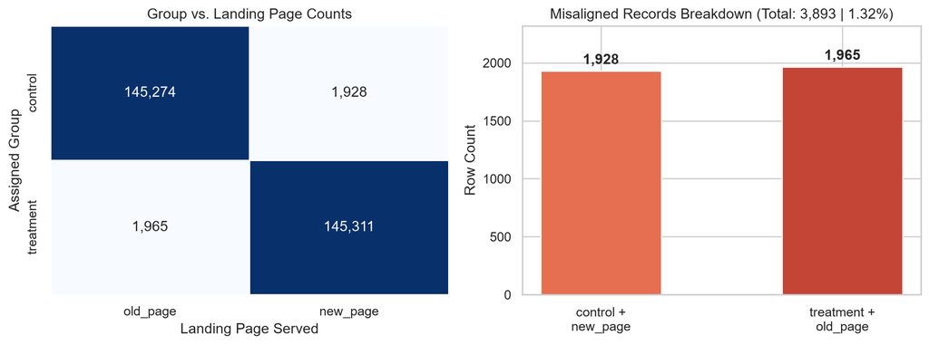

Raw session counts across the four (group, landing_page) combinations, highlighting aligned vs. misaligned records.

```python
fig, axes = plt.subplots(1, 2, figsize=(11, 4.2))

# Left: heatmap of raw counts
heat_data = pd.crosstab(eda_df["group"], eda_df["landing_page"])[["old_page", "new_page"]]
sns.heatmap(
    heat_data,
    annot=True,
    fmt=",",
    cmap="Blues",
    cbar=False,
    linewidths=1,
    ax=axes[0],
)
axes[0].set_title("Group vs. Landing Page Counts")
axes[0].set_xlabel("Landing Page Served")
axes[0].set_ylabel("Assigned Group")

# Right: zoomed bar chart of misaligned records
mis_counts = pd.Series(
    {
        "control +\nnew_page": int(
            ((eda_df["group"] == "control") & (eda_df["landing_page"] == "new_page")).sum()
        ),
        "treatment +\nold_page": int(
            ((eda_df["group"] == "treatment") & (eda_df["landing_page"] == "old_page")).sum()
        ),
    }
)
bars = axes[1].bar(
    mis_counts.index,
    mis_counts.values,
    color=[PALETTE["misaligned"], "#c44536"],
    width=0.5,
)
for bar in bars:
    h = bar.get_height()
    axes[1].text(
        bar.get_x() + bar.get_width() / 2,
        h + 35,
        f"{int(h):,}",
        ha="center",
        va="bottom",
        fontweight="bold",
    )
axes[1].set_title(f"Misaligned Records Breakdown (Total: {n_misaligned:,} | {pct_misaligned:.2f}%)")
axes[1].set_ylabel("Row Count")
axes[1].set_ylim(0, mis_counts.max() * 1.18)

plt.tight_layout()
plt.show()
```

### 4.2 Duplicate `user_id` Audit & Overlap with Misalignment

Next, we inspect how repeated `user_id` entries behave and how they intersect with the `3,893` misaligned rows.

```python
n_unique_users = eda_df["user_id"].nunique()
n_extra_rows = len(eda_df) - n_unique_users
user_freq_dist = (
    eda_df["user_id"]
    .value_counts()
    .value_counts()
    .sort_index()
    .rename_axis("Appearances per user_id")
    .reset_index(name="Number of Users")
)
user_freq_dist["Total Rows Represented"] = (
    user_freq_dist["Appearances per user_id"] * user_freq_dist["Number of Users"]
)
user_freq_dist
```

|  | Appearances per user_id | Number of Users | Total Rows Represented |
| --- | --- | --- | --- |
| 0 | 1 | 286690 | 286690 |
| 1 | 2 | 3894 | 7788 |

```python
# Cross-tabulate misaligned status against duplicate user_id membership
overlap_ct = pd.crosstab(
    eda_df["misaligned"].map({False: "Aligned Row", True: "Misaligned Row"}),
    eda_df["is_dup_user"].map({False: "Unique user_id", True: "Duplicated user_id"}),
    margins=True,
    margins_name="Total",
)
overlap_ct
```

| is_dup_user misaligned | Duplicated user_id | Unique user_id | Total |
| --- | --- | --- | --- |
| Aligned Row | 3895 | 286690 | 290585 |
| Misaligned Row | 3893 | 0 | 3893 |
| Total | 7788 | 286690 | 294478 |

Every single misaligned row (`3,893` of `3,893`) belongs to a duplicated `user_id`. To understand *why* these users appear twice, we classify all `3,894` duplicated users by their assignment pattern across their two records:

```python
dup_rows = eda_df[eda_df["is_dup_user"]].sort_values(["user_id", "ts"])
dup_user_patterns = (
    dup_rows.groupby("user_id")
    .agg(
        rows=("user_id", "size"),
        n_groups=("group", "nunique"),
        n_pages=("landing_page", "nunique"),
        misaligned_rows=("misaligned", "sum"),
        distinct_outcomes=("converted", "nunique"),
    )
    .value_counts()
    .reset_index(name="User Count")
)

def describe_pattern(row: pd.Series) -> str:
    if row["misaligned_rows"] == 0:
        return "Both rows aligned (same group & same page)"
    if row["n_groups"] == 1 and row["n_pages"] == 2:
        suffix = "same conversion" if row["distinct_outcomes"] == 1 else "conflicting conversion"
        return f"Same group, saw both pages (1 aligned, 1 misaligned; {suffix})"
    if row["n_groups"] == 2 and row["n_pages"] == 1:
        suffix = "same conversion" if row["distinct_outcomes"] == 1 else "conflicting conversion"
        return f"Switched group, same page (1 aligned, 1 misaligned; {suffix})"
    return "Other"

dup_user_patterns["Pattern Description"] = dup_user_patterns.apply(describe_pattern, axis=1)
dup_user_patterns[["Pattern Description", "User Count"]]
```

|  | Pattern Description | User Count |
| --- | --- | --- |
| 0 | Same group, saw both pages (1 aligned, 1 misal... | 1548 |
| 1 | Switched group, same page (1 aligned, 1 misali... | 1481 |
| 2 | Same group, saw both pages (1 aligned, 1 misal... | 450 |
| 3 | Switched group, same page (1 aligned, 1 misali... | 414 |
| 4 | Both rows aligned (same group & same page) | 1 |

#### 4.2.1 Concrete Examples of Duplicated User Records

Inspecting concrete examples makes the logging artifact immediately clear:

```python
# Sample one user from each major pattern + the single fully aligned duplicate user
aligned_only_dup_ids = (
    eda_df[~eda_df["misaligned"]]
    .loc[lambda d: d["user_id"].duplicated(keep=False), "user_id"]
    .unique()
    .tolist()
)

same_group_two_pages_id = (
    dup_rows.groupby("user_id")
    .filter(lambda g: g["group"].nunique() == 1 and g["landing_page"].nunique() == 2)["user_id"]
    .iloc[0]
)

two_groups_same_page_id = (
    dup_rows.groupby("user_id")
    .filter(lambda g: g["group"].nunique() == 2 and g["landing_page"].nunique() == 1)["user_id"]
    .iloc[0]
)

example_ids = [same_group_two_pages_id, two_groups_same_page_id] + aligned_only_dup_ids
eda_df[eda_df["user_id"].isin(example_ids)][
    ["user_id", "timestamp", "group", "landing_page", "converted", "misaligned"]
].sort_values(["user_id", "timestamp"])
```

|  | user_id | timestamp | group | landing_page | converted | misaligned |
| --- | --- | --- | --- | --- | --- | --- |
| 213114 | 630052 | 2017-01-07 12:25:54.089486 | treatment | old_page | 1 | True |
| 230259 | 630052 | 2017-01-17 01:16:05.208766 | treatment | new_page | 0 | False |
| 207211 | 630320 | 2017-01-07 18:02:43.626318 | control | old_page | 0 | False |
| 255753 | 630320 | 2017-01-12 05:27:37.181803 | treatment | old_page | 0 | True |
| 1899 | 773192 | 2017-01-09 05:37:58.781806 | treatment | new_page | 0 | False |
| 2893 | 773192 | 2017-01-14 02:55:59.590927 | treatment | new_page | 0 | False |

**ImportantCritical Integrity Discovery**

1. **3,893 users** appear twice with **one aligned record and one misaligned record** — roughly half kept the same `group` while seeing both pages (`1,998` users), and roughly half switched `group` while seeing the same page (`1,895` users). Furthermore, **864 of these users** have conflicting `converted` values (`0` on one row, `1` on the other).
2. **1 additional user** (`user_id = 773192`) appears twice with **both rows properly aligned** (`treatment` + `new_page`, ~5 days apart).
3. Simply removing misaligned rows in Phase 2 would still leave that 1 duplicate user unless explicit deduplication rules are applied.

## 5 Temporal Coverage & Traffic Patterns

Next, we inspect the experiment timeline to check duration, boundary-day completeness, daily traffic stability, and whether misaligned logging was a localized incident or an ongoing issue.

```python
ts_min = eda_df["ts"].min()
ts_max = eda_df["ts"].max()
duration = ts_max - ts_min

time_summary = pd.DataFrame(
    {
        "Metric": [
            "Earliest Timestamp",
            "Latest Timestamp",
            "Total Elapsed Duration",
            "Calendar Dates Spanned",
            "Full 24-Hour Interior Dates",
        ],
        "Value": [
            str(ts_min),
            str(ts_max),
            f"{duration.days} days, {duration.seconds // 3600} hours, {(duration.seconds % 3600) // 60} minutes",
            f"{eda_df['date'].nunique()} calendar dates ({ts_min.date()} to {ts_max.date()})",
            f"{eda_df['date'].nunique() - 2} full days (first and last days are partial)",
        ],
    }
)
time_summary
```

|  | Metric | Value |
| --- | --- | --- |
| 0 | Earliest Timestamp | 2017-01-02 13:42:05.378582 |
| 1 | Latest Timestamp | 2017-01-24 13:41:54.460509 |
| 2 | Total Elapsed Duration | 21 days, 23 hours, 59 minutes |
| 3 | Calendar Dates Spanned | 23 calendar dates (2017-01-02 to 2017-01-24) |
| 4 | Full 24-Hour Interior Dates | 21 full days (first and last days are partial) |

```python
daily_stats = (
    eda_df.groupby("date")
    .agg(
        total_rows=("user_id", "size"),
        control_rows=("group", lambda s: (s == "control").sum()),
        treatment_rows=("group", lambda s: (s == "treatment").sum()),
        misaligned_rows=("misaligned", "sum"),
        raw_conv_rate=("converted", "mean"),
    )
    .reset_index()
)
daily_stats["misaligned_pct"] = daily_stats["misaligned_rows"] / daily_stats["total_rows"] * 100
daily_stats["treatment_share_pct"] = daily_stats["treatment_rows"] / daily_stats["total_rows"] * 100

# Display compact summary table of daily traffic
daily_display = daily_stats.copy()
daily_display["date"] = daily_display["date"].dt.strftime("%Y-%m-%d")
daily_display["misaligned_pct"] = daily_display["misaligned_pct"].round(2)
daily_display["treatment_share_pct"] = daily_display["treatment_share_pct"].round(2)
daily_display["raw_conv_rate (%)"] = (daily_display["raw_conv_rate"] * 100).round(2)
daily_display[
    [
        "date",
        "total_rows",
        "control_rows",
        "treatment_rows",
        "treatment_share_pct",
        "misaligned_rows",
        "misaligned_pct",
        "raw_conv_rate (%)",
    ]
]
```

|  | date | total_rows | control_rows | treatment_rows | treatment_share_pct | misaligned_rows | misaligned_pct | raw_conv_rate (%) |
| --- | --- | --- | --- | --- | --- | --- | --- | --- |
| 0 | 2017-01-02 | 5783 | 2894 | 2889 | 49.96 | 71 | 1.23 | 12.28 |
| 1 | 2017-01-03 | 13394 | 6684 | 6710 | 50.10 | 186 | 1.39 | 11.36 |
| 2 | 2017-01-04 | 13284 | 6655 | 6629 | 49.90 | 165 | 1.24 | 11.92 |
| 3 | 2017-01-05 | 13124 | 6538 | 6586 | 50.18 | 192 | 1.46 | 11.88 |
| 4 | 2017-01-06 | 13528 | 6684 | 6844 | 50.59 | 175 | 1.29 | 12.02 |
| 5 | 2017-01-07 | 13381 | 6678 | 6703 | 50.09 | 168 | 1.26 | 11.82 |
| 6 | 2017-01-08 | 13564 | 6769 | 6795 | 50.10 | 177 | 1.30 | 11.99 |
| 7 | 2017-01-09 | 13439 | 6725 | 6714 | 49.96 | 196 | 1.46 | 11.91 |
| 8 | 2017-01-10 | 13523 | 6745 | 6778 | 50.12 | 173 | 1.28 | 11.99 |
| 9 | 2017-01-11 | 13553 | 6787 | 6766 | 49.92 | 192 | 1.42 | 11.75 |
| 10 | 2017-01-12 | 13322 | 6615 | 6707 | 50.35 | 163 | 1.22 | 12.23 |
| 11 | 2017-01-13 | 13238 | 6649 | 6589 | 49.77 | 178 | 1.34 | 11.43 |
| 12 | 2017-01-14 | 13329 | 6635 | 6694 | 50.22 | 181 | 1.36 | 12.31 |
| 13 | 2017-01-15 | 13449 | 6809 | 6640 | 49.37 | 186 | 1.38 | 11.75 |
| 14 | 2017-01-16 | 13327 | 6683 | 6644 | 49.85 | 191 | 1.43 | 12.09 |
| 15 | 2017-01-17 | 13322 | 6691 | 6631 | 49.77 | 167 | 1.25 | 12.48 |
| 16 | 2017-01-18 | 13285 | 6578 | 6707 | 50.49 | 200 | 1.51 | 12.46 |
| 17 | 2017-01-19 | 13293 | 6665 | 6628 | 49.86 | 163 | 1.23 | 11.85 |
| 18 | 2017-01-20 | 13393 | 6626 | 6767 | 50.53 | 180 | 1.34 | 11.65 |
| 19 | 2017-01-21 | 13475 | 6823 | 6652 | 49.37 | 166 | 1.23 | 12.10 |
| 20 | 2017-01-22 | 13423 | 6675 | 6748 | 50.27 | 158 | 1.18 | 11.85 |
| 21 | 2017-01-23 | 13511 | 6783 | 6728 | 49.80 | 162 | 1.20 | 12.35 |
| 22 | 2017-01-24 | 7538 | 3811 | 3727 | 49.44 | 103 | 1.37 | 11.94 |

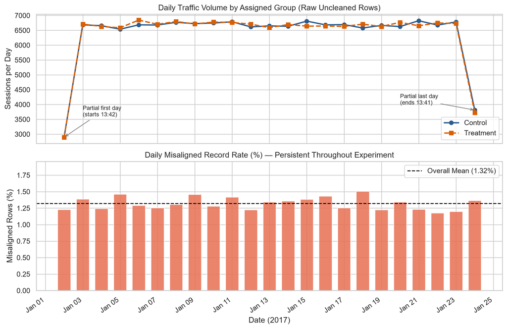

Daily session volume by assigned group (top) and daily misaligned record rate (bottom) across the 22-day window.

```python
fig, axes = plt.subplots(2, 1, figsize=(11, 7.2), sharex=True)

# Top panel: daily traffic volume by group
axes[0].plot(
    daily_stats["date"],
    daily_stats["control_rows"],
    marker="o",
    linewidth=2,
    color=PALETTE["control"],
    label="Control",
)
axes[0].plot(
    daily_stats["date"],
    daily_stats["treatment_rows"],
    marker="s",
    linewidth=2,
    linestyle="--",
    color=PALETTE["treatment"],
    label="Treatment",
)
axes[0].set_title("Daily Traffic Volume by Assigned Group (Raw Uncleaned Rows)")
axes[0].set_ylabel("Sessions per Day")
axes[0].legend(frameon=True)
axes[0].annotate(
    "Partial first day\n(starts 13:42)",
    xy=(daily_stats["date"].iloc[0], daily_stats["control_rows"].iloc[0]),
    xytext=(daily_stats["date"].iloc[1], 3600),
    arrowprops={"arrowstyle": "->", "color": "gray"},
    fontsize=9,
)
axes[0].annotate(
    "Partial last day\n(ends 13:41)",
    xy=(daily_stats["date"].iloc[-1], daily_stats["control_rows"].iloc[-1]),
    xytext=(daily_stats["date"].iloc[-5], 4000),
    arrowprops={"arrowstyle": "->", "color": "gray"},
    fontsize=9,
)

# Bottom panel: daily misalignment rate
overall_mis_pct = eda_df["misaligned"].mean() * 100
axes[1].bar(
    daily_stats["date"],
    daily_stats["misaligned_pct"],
    color=PALETTE["misaligned"],
    alpha=0.85,
    width=0.7,
)
axes[1].axhline(
    overall_mis_pct,
    color="black",
    linestyle="--",
    linewidth=1.3,
    label=f"Overall Mean ({overall_mis_pct:.2f}%)",
)
axes[1].set_title("Daily Misaligned Record Rate (%) — Persistent Throughout Experiment")
axes[1].set_ylabel("Misaligned Rows (%)")
axes[1].set_xlabel("Date (2017)")
axes[1].set_ylim(0, max(daily_stats["misaligned_pct"]) * 1.3)
axes[1].legend(frameon=True)

axes[1].xaxis.set_major_locator(mdates.DayLocator(interval=2))
axes[1].xaxis.set_major_formatter(mdates.DateFormatter("%b %d"))
plt.xticks(rotation=35, ha="right")
plt.tight_layout()
plt.show()
```

**Temporal Takeaways:**

- **Duration & stability:** The experiment ran for almost exactly **22.0 days** (`2017-01-02 13:42` to `2017-01-24 13:41`). Across all 21 full interior days, total daily traffic was highly consistent (~`13,000`–`13,564` rows/day) with no visible logging outages, ramp-up periods, or abrupt traffic spikes.
- **Persistent misalignment:** Misaligned rows occur steadily every single day (`1.18%` to `1.51%` of daily traffic), ruling out a single-day deployment glitch and pointing instead to a persistent routing/logging bug.

## 6 Descriptive Conversion Overview (Raw / Uncleaned)

To establish initial descriptive context against FaceZonGoogAppFlix’s **12.00% baseline**, we inspect raw conversion rates across groups, landing pages, the full 2×2 breakdown, and daily trends.

**CautionRaw Exploratory Figures Only**

All conversion rates below are computed on the **uncleaned raw dataset** (including misaligned and duplicated records) and carry **no statistical significance claims**. Formal estimation and testing belong in Phase 2 after data-cleaning rules are finalized.

```python
overall_conv = eda_df["converted"].mean()

by_group = (
    eda_df.groupby("group", as_index=False)
    .agg(rows=("converted", "size"), conversions=("converted", "sum"), conv_rate=("converted", "mean"))
    .assign(dimension="group")
    .rename(columns={"group": "segment"})
)

by_page = (
    eda_df.groupby("landing_page", as_index=False)
    .agg(rows=("converted", "size"), conversions=("converted", "sum"), conv_rate=("converted", "mean"))
    .assign(dimension="landing_page")
    .rename(columns={"landing_page": "segment"})
)

overall_row = pd.DataFrame(
    {
        "dimension": ["overall"],
        "segment": ["all_rows"],
        "rows": [len(eda_df)],
        "conversions": [int(eda_df["converted"].sum())],
        "conv_rate": [overall_conv],
    }
)

marginal_conv = pd.concat([overall_row, by_group, by_page], ignore_index=True)
marginal_conv["conv_rate (%)"] = (marginal_conv["conv_rate"] * 100).round(3)
marginal_conv["diff_vs_12pct_baseline (pp)"] = ((marginal_conv["conv_rate"] - 0.12) * 100).round(3)
marginal_conv[["dimension", "segment", "rows", "conversions", "conv_rate (%)", "diff_vs_12pct_baseline (pp)"]]
```

|  | dimension | segment | rows | conversions | conv_rate (%) | diff_vs_12pct_baseline (pp) |
| --- | --- | --- | --- | --- | --- | --- |
| 0 | overall | all_rows | 294478 | 35237 | 11.966 | -0.034 |
| 1 | group | control | 147202 | 17723 | 12.040 | 0.040 |
| 2 | group | treatment | 147276 | 17514 | 11.892 | -0.108 |
| 3 | landing_page | new_page | 147239 | 17498 | 11.884 | -0.116 |
| 4 | landing_page | old_page | 147239 | 17739 | 12.048 | 0.048 |

### 6.1 2×2 Breakdown (`group` × `landing_page`)

```python
cell_conv = (
    eda_df.groupby(["group", "landing_page"], as_index=False)
    .agg(rows=("converted", "size"), conversions=("converted", "sum"), conv_rate=("converted", "mean"))
)
cell_conv["status"] = np.where(
    ((cell_conv["group"] == "control") & (cell_conv["landing_page"] == "old_page"))
    | ((cell_conv["group"] == "treatment") & (cell_conv["landing_page"] == "new_page")),
    "Aligned",
    "Misaligned",
)
cell_conv["conv_rate (%)"] = (cell_conv["conv_rate"] * 100).round(3)
cell_conv[["group", "landing_page", "status", "rows", "conversions", "conv_rate (%)"]]
```

|  | group | landing_page | status | rows | conversions | conv_rate (%) |
| --- | --- | --- | --- | --- | --- | --- |
| 0 | control | new_page | Misaligned | 1928 | 234 | 12.137 |
| 1 | control | old_page | Aligned | 145274 | 17489 | 12.039 |
| 2 | treatment | new_page | Aligned | 145311 | 17264 | 11.881 |
| 3 | treatment | old_page | Misaligned | 1965 | 250 | 12.723 |

### 6.2 Daily Raw Conversion Rate Trend by Group

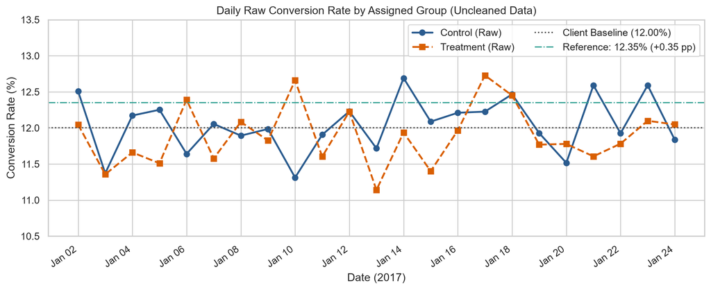

Daily raw conversion rate by assigned group compared against the client’s 12.00% historical baseline and a 12.35% (+0.35 pp) reference line.

```python
daily_group_conv = (
    eda_df.groupby(["date", "group"], as_index=False)["converted"]
    .mean()
    .assign(conv_pct=lambda d: d["converted"] * 100)
)

fig, ax = plt.subplots(figsize=(11, 4.6))
for grp, marker, ls in [("control", "o", "-"), ("treatment", "s", "--")]:
    sub = daily_group_conv[daily_group_conv["group"] == grp]
    ax.plot(
        sub["date"],
        sub["conv_pct"],
        marker=marker,
        linestyle=ls,
        linewidth=2,
        color=PALETTE[grp],
        label=f"{grp.title()} (Raw)",
    )

ax.axhline(12.00, color="#444444", linestyle=":", linewidth=1.4, label="Client Baseline (12.00%)")
ax.axhline(
    12.35,
    color="#2a9d8f",
    linestyle="-.",
    linewidth=1.2,
    label="Reference: 12.35% (+0.35 pp)",
)

ax.set_title("Daily Raw Conversion Rate by Assigned Group (Uncleaned Data)")
ax.set_ylabel("Conversion Rate (%)")
ax.set_xlabel("Date (2017)")
ax.set_ylim(10.5, 13.5)
ax.legend(ncol=2, frameon=True, loc="upper right")

ax.xaxis.set_major_locator(mdates.DayLocator(interval=2))
ax.xaxis.set_major_formatter(mdates.DateFormatter("%b %d"))
plt.xticks(rotation=35, ha="right")
plt.tight_layout()
plt.show()
```

**Descriptive Observations:**

- The raw overall conversion rate (`11.97%`) aligns closely with FaceZonGoogAppFlix’s stated **12.00%** historical baseline.
- Descriptively, the raw `treatment` / `new_page` rate (`11.88%`–`11.89%`) sits slightly *below* `control` / `old_page` (`12.04%`–`12.05%`) and below the `12.35%` (+0.35 pp) reference line, with no obvious upward novelty surge across the 22-day period.
- Whether this observed gap is statistically meaningful—or how cleaning misaligned/duplicated users affects the estimate—must wait for formal Phase 2 analysis.

## 7 Summary of Findings & Handoff to Phase 2

### 7.1 Data Quality & Exploration Summary

| Finding Area | Observation | Severity | Phase 2 Implication |
| --- | --- | --- | --- |
| **File Structure** | CSV is nested at `ab_data.csv/ab_data.csv` (`294,478` rows × `5` cols) | Low | Standardize data path in cleaning pipeline |
| **Completeness & Schema** | `0` nulls, `0` exact duplicate rows, valid binary target and timestamps | Clean | No imputation required |
| **Group/Page Misalignment** | `3,893` rows (`1.32%`) have mismatched `group` & `landing_page`, persistently across all 22 days | **High** | Define and justify exclusion rule; verify with client engineering |
| **Duplicate `user_id`s** | `3,894` users appear twice (`7,788` rows): `3,893` overlap with misaligned rows (`864` with conflicting conversions) + `1` aligned duplicate (`user_id = 773192`) | **High** | Decide whether to drop misaligned rows + deduplicate, or exclude all dual-exposed users completely |
| **Experiment Window** | ~22.0 days (`2017-01-02 13:42` to `2017-01-24 13:41`); partial first and last calendar days | Medium | Note partial boundary days when running time-sliced diagnostics |
| **Raw Conversion Context** | Raw control `12.04%` vs. raw treatment `11.89%` (vs. `12.00%` baseline) | Info | Proceed to formal hypothesis test after cleaning |

### 7.2 Open Questions for FaceZonGoogAppFlix Stakeholders

1. **Target lift definition:** Does “increase 12% by 0.35% or more” mean **+0.35 percentage points** (`12.35%`) or a **+0.35% relative lift** (`12.042%`)?
2. **Root cause of misaligned logs:** Why did ~1.32% of daily records log a `control` user on `new_page` or a `treatment` user on `old_page`—and why did those exact `3,893` users also receive an aligned record? (e.g., cookie reset, cross-device login, bucketing race condition?)
3. **Repeat-visit policy:** Should users who were exposed to *both* pages (`1,998` users) or switched groups (`1,895` users) be excluded entirely from the experiment (contaminated units), rather than keeping their aligned row?

### 7.3 Next Steps (Phase 2 Checklist)

- Finalize data-cleaning and deduplication rules based on stakeholder input.
- Run a formal **Sample Ratio Mismatch (SRM)** check on the cleaned assignment counts.
- Perform **power & minimum detectable effect (MDE)** calculations given the confirmed lift definition.
- Execute formal **hypothesis testing** (two-proportion test, effect-size confidence interval) and deliver a launch recommendation.